# *Curriculum vitae* **Caitlin M Davis**

### Education

BA Biology, Goucher College  
MS Raptor Biology, Boise State University

### Publications

**Davis, C. M.**, J.A. Heath. 2022. Treatment of nest parasites as a mitigation option for eagle take permits. *Manuscript in prep*.  
**Davis, C. M.**, R. Spaul, J.A. Heath. 2022. Recreation, fire, and disease create a mosaic of threats for an apex predator in a shrub-steppe ecosystem. *Manuscript in review*.  
**Davis, C. M.**, J.A. Heath. 2019. Recreation, fire and disease create a mosaic of threats for golden eagles in southwestern Idaho. M.Sc. Thesis. Boise State University. Boise, ID, USA.  
**Davis, C. M.**, J. A. Heath, and C. J. W. McClure. 2017. Nest box use by American Kestrels and other cavity-nesting birds during the nonbreeding season. Avian Conservation and Ecology. 12(2):5  
Robinson, B. W. and **C. M. Davis**. 2014. A Communal Roosting of the Great Horned Owl- *Bubo virginianus*. Journal of Raptor Research 48(1): 88-89

### Employment

**2019**- Present; Research Associate, Golden Eagle Project Manager, Boise State University, ID  
**2016- 2019**; Graduate Teaching Assistant, Boise State University, ID  
**2014- 2019**; Raptor Research Technician, Boise State University, ID  
**2014- 2016**; Avian Research Technician, USGS Alaska Science Center, Seward Peninsula, AK  
**2016**; Raptor Migration Counter, HawkWatch Int., Gunsight Mountain, AK  
**2014- 2015**; Site Coordinator & Lead Bander, HawkWatch Int., Goshute Mountains, NV  
**2012- 2013**; Raptor Migration Technician, HawkWatch Int., Goshute Mountains, NV  
**2013**; Avian Research Technician, Wildlife Conservation Society, Prudhoe Bay, AK  
**2013**; Quail Research Technician, Rolling Plains Quail Research Ranch, Roby, TX  
**2012**; Spotted Owl Research Technician, University of Wisconsin- Madison, Eldorado National Forest, CA  
**2011- 2012**; Waterfowl Research Technician, University of Delaware, Coastal DE  
**2011**; Sage-grouse Research Technician, Colorado Division of Wildlife, Gunnison, CO  
**2010**; Antbird Lab Technician, Smithsonian Tropical Research Institute, Gamboa, Panama

### Teaching

**2022** Raptor Research Foundation Annual Conference workshop instructor: Advanced Molt & Aging in Raptors  
**2016- 2019** Laboratory instructor: Human Anatomy and Physiology I & II

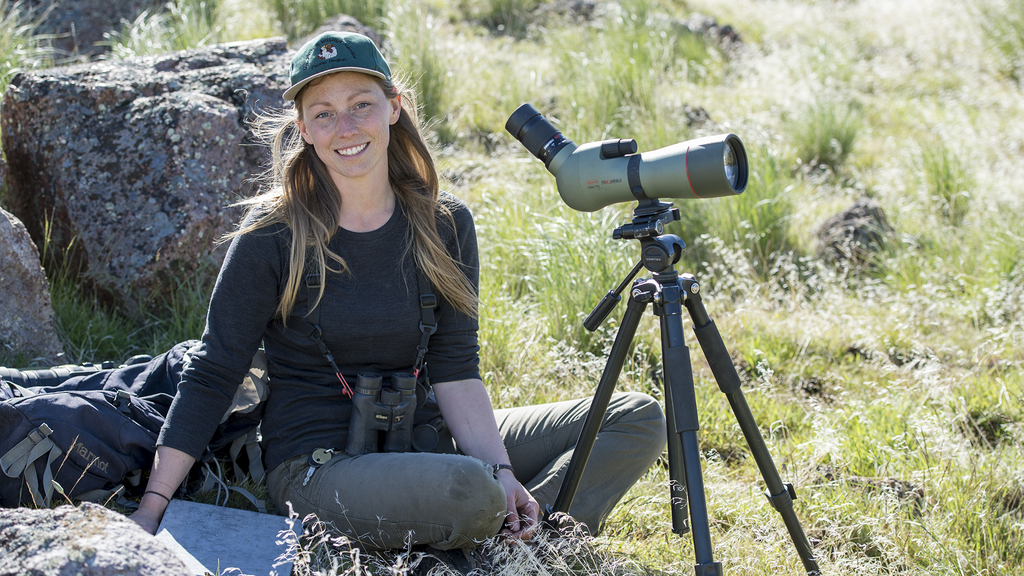